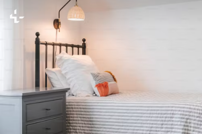

### [*Click to view the analysis*](https://business-analytics-slee.shinyapps.io/data_models_decisions_marketing_mle_2/)

## **Take a quick glance of this case study and analysis.**

**What kind of problem are we solving, what is the story?**

- We’re examining Airbnb listings in New York City to gain insights into the rental market. In March 2017, students Annika Awad, Evan Lebo, and Anna Linden scraped data from 40,000 Airbnb listings. The dataset provides a comprehensive view of Airbnb rentals in NYC, which can be analyzed to understand trends, pricing, location distribution, and other rental-related factors. This study forms part of a project for the UC San Diego, MSBA program; MGTA 495 - Marketing Analytics course.

**What is the goal of the analysis?**

- This analysis aims to identify the most profitable Airbnb business model by examining how room type affects pricing strategies and guest feedback, focusing on median prices, price spread, and outliers across Private rooms, Entire homes/apartments, and Shared rooms. The analysis will provide insights into the most profitable room type and help guide marketing strategies by identifying the most effective methods for promoting Airbnb listings to potential guests.

Copyright © 2023- 2024 Sangho Lee, All rights reserved.